# Dnyanai_Surkutwar_Take_Home_test

### 4.5.4. Between "race", "age" and "yearly_income":

```python
df.race.value_counts()/len(df)*100
```

```
White                 85.607893
Black                  9.443741
Asian-Pac-Islander     3.197819
Amer-Indian-Eskimo     0.971246
Other                  0.779301
Name: race, dtype: float64
```

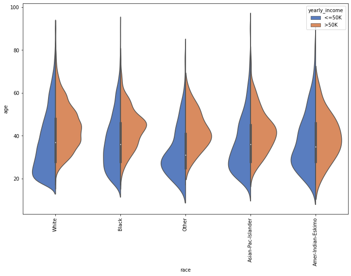

```python
plt.figure(figsize=(12,8))
splot = sns.violinplot(x="race", y="age", hue="yearly_income",
                    data=df, gridsize=100, palette="muted", split=True, saturation=0.75)
plt.xticks(None, None, rotation='vertical')
plt.show()
```

### 4.5.5. Between "race", "hours_per_week" and "yearly_income":

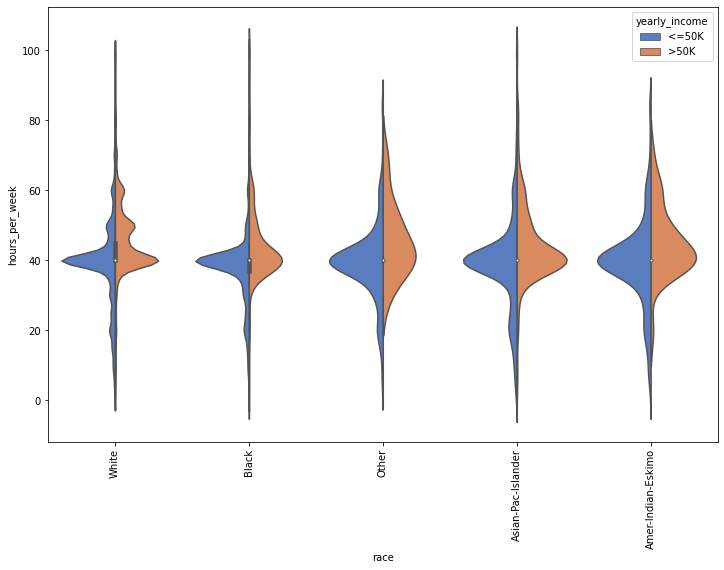

```python
plt.figure(figsize=(12,8))
splot = sns.violinplot(x="race", y="hours_per_week", hue="yearly_income",
                    data=df, gridsize=100, palette="muted", split=True, saturation=0.75)
plt.xticks(None, None, rotation='vertical')
plt.show()
```

#### Observations: One thing to note is that Caucasian population is covers almost 86% of the data, so the above observations will be biased since we do not have decent amount of data from other races to conclude with 100% confidence. The graphs above show that employees from all races have high paying jobs in the age group from 35-45 with aorund the same hours_per_week i.e 40 hrs.

```python
df.columns
```

```
Index(['rowid', 'age', 'workclass', 'fnlwgt', 'education', 'education_num',
       'marital_status', 'occupation', 'relationship', 'race', 'sex',
       'capital_gain', 'capital_loss', 'hours_per_week', 'native_country',
       'yearly_income', 'age_range', 'education_level', 'country',
       'change_capital', 'target'],
      dtype='object')
```

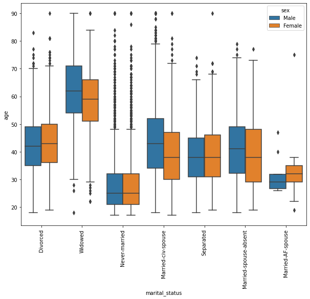

```python
plt.figure(figsize=(10,8))
splot = sns.boxplot(x='marital_status',y ='age', hue='sex',data=df, fliersize=5)
plt.xticks(None, None, rotation='vertical')
plt.show()
```

```python
df.marital_status.value_counts()
```

```
Married-civ-spouse       11994
Never-married             8513
Divorced                  3585
Separated                  801
Widowed                    784
Married-spouse-absent      353
Married-AF-spouse           19
Name: marital_status, dtype: int64
```

# 5. Lets make a new df for model and drop all the redundant features not required for the model: back

```python
df1 = df.copy(deep=True)
```

```python
df1.columns
```

```
Index(['rowid', 'age', 'workclass', 'fnlwgt', 'education', 'education_num',
       'marital_status', 'occupation', 'relationship', 'race', 'sex',
       'capital_gain', 'capital_loss', 'hours_per_week', 'native_country',
       'yearly_income', 'age_range', 'education_level', 'country',
       'change_capital', 'target'],
      dtype='object')
```

```python
df1.shape
```

```
(26049, 21)
```

```python
df1.drop(columns=['age_range','capital_gain','capital_loss', 'education', 'education_num', \
                  'rowid', 'fnlwgt', 'yearly_income', 'native_country']\
         , axis=1, inplace=True)
```

```python
df1.shape
```

```
(26049, 12)
```

```python
df1.info()
```

```
<class 'pandas.core.frame.DataFrame'>
RangeIndex: 26049 entries, 0 to 26048
Data columns (total 12 columns):
 #   Column           Non-Null Count  Dtype
---  ------           --------------  -----
 0   age              26049 non-null  int64
 1   workclass        26049 non-null  object
 2   marital_status   26049 non-null  object
 3   occupation       26049 non-null  object
 4   relationship     26049 non-null  object
 5   race             26049 non-null  object
 6   sex              26049 non-null  object
 7   hours_per_week   26049 non-null  int64
 8   education_level  26049 non-null  object
 9   country          26049 non-null  int64
 10  change_capital   26049 non-null  int64
 11  target           26049 non-null  int64
dtypes: int64(5), object(7)
memory usage: 2.4+ MB
```

# 6. Section 3- Prepping data for making a KNN model: back

### 6.1. All the repeated plotting functions in this section:

1) Confusion Matrix function, confmatrix():

```python
def confmatrix(cm, k):
  plt.figure(figsize=(10,8))
  sns.heatmap(cm, annot=True, fmt='.0f', cmap='Blues')
  plt.title('Confusion Matrix')
  plt.xlabel('Predicted Labels')
  plt.ylabel('True Labels')
  plt.show()
```

### 6.2. Creating two separate dataframes one for categorical columns other for numerical columns:

```python
df1.columns
```

```
Index(['age', 'workclass', 'marital_status', 'occupation', 'relationship',
       'race', 'sex', 'hours_per_week', 'education_level', 'country',
       'change_capital', 'target'],
      dtype='object')
```

```python
df_cat = df1.select_dtypes(include='object')
df_num = df1.select_dtypes(exclude='object')
print('Dataframe of numerical features:',df_num.shape)
print('dataframe of categorical features:',df_cat.shape)
```

```
Dataframe of numerical features: (26049, 5)
dataframe of categorical features: (26049, 7)
```

#### 6.2.1. Standardizing the data: (As discussed previously, we will frist Standardize the numerical features in df_num)

```python
## We are manually doing this as we do not want to use the scaler from scikitlearn
##as before splitting our data the scaler will know the data and this shouldnt happen to the test data we split from the training data
for i in df_num.drop(columns='target').columns:
    df_num.loc[:,i] = (df_num.loc[:,i]-np.mean(df_num.loc[:,i]))/(np.std(df_num.loc[:,i]))
```

```python
df_num.head()
```

|  | age | hours_per_week | country | change_capital | target |
| --- | --- | --- | --- | --- | --- |
| 0 | -0.043284 | -0.035376 | 0.308149 | -0.133559 | 0 |
| 1 | 1.425780 | 3.187499 | 0.308149 | -0.133559 | 0 |
| 2 | 1.719592 | -0.035376 | 0.308149 | -0.133559 | 0 |
| 3 | 1.058514 | 1.173202 | 0.308149 | -0.133559 | 1 |
| 4 | 0.103622 | -0.438235 | 0.308149 | -0.133559 | 0 |

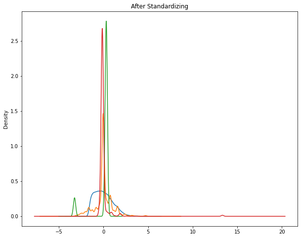

```python
## We already know that this dataset is biased and we cannot change that much but now its in the same scale:
plt.figure(figsize=(10,8))
for each in df_num.drop(columns='target'):
  plt.title('After Standardizing')
  df_num[each].plot(kind='kde')
```

### 6.3. One-hot encoding the categorical dataframe df_cat (we are right now keeping all the categorical features):

#### If we did not decrease the feature space above then the feature space for just categorical columns is very big. KNN takes a lot of computation time thus part of data transformation for KNN is already done in section [4.3]. This makes our feature space with 50 columns instead of 80+ columns.

```python
df_cat = pd.get_dummies(df_cat) ##get_dummies is used for one-hot encoding
```

```python
df_cat.shape
```

```
(26049, 50)
```

```python
df_cat.head()
```

|  | workclass_Federal-gov | workclass_Local-gov | workclass_Never-worked | workclass_Private | workclass_Self-emp-inc | workclass_Self-emp-not-inc | workclass_State-gov | workclass_Without-pay | marital_status_Divorced | marital_status_Married-AF-spouse | marital_status_Married-civ-spouse | marital_status_Married-spouse-absent | marital_status_Never-married | marital_status_Separated | marital_status_Widowed | occupation_Adm-clerical | occupation_Armed-Forces | occupation_Craft-repair | occupation_Exec-managerial | occupation_Farming-fishing | occupation_Handlers-cleaners | occupation_Machine-op-inspct | occupation_Other-service | occupation_Priv-house-serv | occupation_Prof-specialty | occupation_Protective-serv | occupation_Sales | occupation_Tech-support | occupation_Transport-moving | … |
| --- | --- | --- | --- | --- | --- | --- | --- | --- | --- | --- | --- | --- | --- | --- | --- | --- | --- | --- | --- | --- | --- | --- | --- | --- | --- | --- | --- | --- | --- | --- |
| 0 | 0 | 0 | 0 | 1 | 0 | 0 | 0 | 0 | 1 | 0 | 0 | 0 | 0 | 0 | 0 | 0 | 0 | 1 | 0 | 0 | 0 | 0 | 0 | 0 | 0 | 0 | 0 | 0 | 0 | … |
| 1 | 0 | 0 | 0 | 0 | 0 | 1 | 0 | 0 | 0 | 0 | 0 | 0 | 0 | 0 | 1 | 0 | 0 | 0 | 0 | 1 | 0 | 0 | 0 | 0 | 0 | 0 | 0 | 0 | 0 | … |
| 2 | 0 | 0 | 0 | 1 | 0 | 0 | 0 | 0 | 0 | 0 | 0 | 0 | 0 | 0 | 1 | 0 | 0 | 1 | 0 | 0 | 0 | 0 | 0 | 0 | 0 | 0 | 0 | 0 | 0 | … |
| 3 | 0 | 0 | 0 | 1 | 0 | 0 | 0 | 0 | 1 | 0 | 0 | 0 | 0 | 0 | 0 | 0 | 0 | 0 | 1 | 0 | 0 | 0 | 0 | 0 | 0 | 0 | 0 | 0 | 0 | … |
| 4 | 0 | 1 | 0 | 0 | 0 | 0 | 0 | 0 | 0 | 0 | 0 | 0 | 1 | 0 | 0 | 1 | 0 | 0 | 0 | 0 | 0 | 0 | 0 | 0 | 0 | 0 | 0 | 0 | 0 | … |